# Lab 4 - Individual 2

Adam Ford

10/11/2020

## Loading Data

```r
library(tidyverse)
library(readxl)

defense <- read_excel('cyclonesFootball2019.xlsx', sheet='Defensive')
str(defense)
```

```
## tibble [502 x 11] (S3: tbl_df/tbl/data.frame)
##  $ Name             : chr [1:502] "White, Lawrence" "White, Lawrence" "White, Lawrence" "White, Lawrence" ...
##  $ Opponent_Opponent: chr [1:502] "UNI" "Iowa" "ULM" "Baylor" ...
##  $ Tackles_Solo     : chr [1:502] "4" "4" "3" "4" ...
##  $ Tackles_ASST     : chr [1:502] "4" "7" "5" "2" ...
##  $ Tackles_TFL      : chr [1:502] "0" "0" "0" "0" ...
##  $ Tackles_Sack     : chr [1:502] "0" "0" "0" "0" ...
##  $ Turnover_FF      : chr [1:502] "0" "0" "0" "0" ...
##  $ Turnover_FR      : chr [1:502] "0" "0" "0" "0" ...
##  $ Turnover_INT     : chr [1:502] "0" "0" "1" "0" ...
##  $ Pass_QBH         : chr [1:502] "1" "0" "0" "0" ...
##  $ Pass_PB          : chr [1:502] "1" "2" "0" "0" ...
```

```r
offense <- read_excel('cyclonesFootball2019.xlsx', sheet='Offensive')
str(offense)
```

```
## tibble [195 x 12] (S3: tbl_df/tbl/data.frame)
##  $ Name             : chr [1:195] "Akers, Landen" "Akers, Landen" "Akers, Landen" "Akers, Landen" ...
##  $ Opponent_Opponent: chr [1:195] "UNI" "Iowa" "ULM" "Baylor" ...
##  $ Rushing_ATT      : chr [1:195] "0" "0" "1" "0" ...
##  $ Rushing_YDS      : chr [1:195] "0" "0" "8" "0" ...
##  $ Rushing_TD       : chr [1:195] "0" "0" "0" "0" ...
##  $ Receiving_REC    : chr [1:195] "1" "0" "0" "0" ...
##  $ Receiving_YDS    : chr [1:195] "21" "0" "0" "0" ...
##  $ Receiving_TD     : chr [1:195] "0" "0" "0" "0" ...
##  $ Passing_CMP-ATT  : chr [1:195] NA NA NA NA ...
##  $ Passing_YDS      : chr [1:195] NA NA NA NA ...
##  $ Passing_TD       : chr [1:195] NA NA NA NA ...
##  $ Passing_INT      : chr [1:195] NA NA NA NA ...
```

```r
biography <- read_excel('cyclonesFootball2019.xlsx', sheet='Biography')
str(biography)
```

```
## tibble [105 x 7] (S3: tbl_df/tbl/data.frame)
##  $ Name      : chr [1:105] "Akers, Landen" "Allen, Chase" "Anderson, Ezeriah" "Assalley, Connor" ...
##  $ Position  : chr [1:105] "Wide Receiver" "Tight End" "Wide Receiver" "Placekicker" ...
##  $ Height    : chr [1:105] "6-0" "6-7" "6-5" "6-0" ...
##  $ Weight    : chr [1:105] "188" "245" "204" "195" ...
##  $ Class     : chr [1:105] "Redshirt Senior" "Redshirt Senior" "Redshirt Freshman" "Redshirt Senior" ...
##  $ Hometown  : chr [1:105] "Cedar Rapids, Iowa" "Nixa, Mo." "Seffner, Fla." "Naperville, Ill." ...
##  $ Highschool: chr [1:105] "Washington" "Nixa" "Armwood" "Central" ...
```

## Part one: Cleaning data

The player names and opponent names are factors. All offensive and defensive statistics are numerical. The Weight column in biogrpahy is also numeric. (Optional: Learn to mutate multiple columns systematically using the ?across function in `dplyr) Change the Height column in biogrpahy into numeric. (Hint: Use a unit that works well)

```r
defClean <- defense %>%
              mutate(across(c("Name", "Opponent_Opponent"), as.factor)) %>%
              mutate_if(is.character, as.numeric, na.rm = TRUE)
str(defClean)
```

```
## tibble [502 x 11] (S3: tbl_df/tbl/data.frame)
##  $ Name             : Factor w/ 43 levels "Akers, Landen",..: 40 40 40 40 40 40 40 40 40 40 ...
##  $ Opponent_Opponent: Factor w/ 13 levels "Baylor","Iowa",..: 12 2 11 1 8 13 10 7 6 9 ...
##  $ Tackles_Solo     : num [1:502] 4 4 3 4 3 1 7 3 6 5 ...
##  $ Tackles_ASST     : num [1:502] 4 7 5 2 2 1 1 2 1 5 ...
##  $ Tackles_TFL      : num [1:502] 0 0 0 0 1 0 0 0 1 1 ...
##  $ Tackles_Sack     : num [1:502] 0 0 0 0 0 0 0 0 0 1 ...
##  $ Turnover_FF      : num [1:502] 0 0 0 0 0 0 0 0 0 0 ...
##  $ Turnover_FR      : num [1:502] 0 0 0 0 0 0 0 0 0 0 ...
##  $ Turnover_INT     : num [1:502] 0 0 1 0 0 0 0 0 1 0 ...
##  $ Pass_QBH         : num [1:502] 1 0 0 0 0 0 0 0 1 0 ...
##  $ Pass_PB          : num [1:502] 1 2 0 0 0 1 0 0 0 0 ...
```

```r
offClean <- offense %>%
              mutate(across(c("Name", "Opponent_Opponent"), as.factor)) %>%
              mutate_if(is.character, as.numeric, na.rm = TRUE)
str(offClean)
```

```
## tibble [195 x 12] (S3: tbl_df/tbl/data.frame)
##  $ Name             : Factor w/ 17 levels "Akers, Landen",..: 1 1 1 1 1 1 1 1 1 1 ...
##  $ Opponent_Opponent: Factor w/ 13 levels "Baylor","Iowa",..: 12 2 11 1 8 13 10 7 6 9 ...
##  $ Rushing_ATT      : num [1:195] 0 0 1 0 0 0 0 0 0 0 ...
##  $ Rushing_YDS      : num [1:195] 0 0 8 0 0 0 0 0 0 0 ...
##  $ Rushing_TD       : num [1:195] 0 0 0 0 0 0 0 0 0 0 ...
##  $ Receiving_REC    : num [1:195] 1 0 0 0 1 0 0 4 0 1 ...
##  $ Receiving_YDS    : num [1:195] 21 0 0 0 32 0 0 39 0 7 ...
##  $ Receiving_TD     : num [1:195] 0 0 0 0 0 0 0 0 0 0 ...
##  $ Passing_CMP-ATT  : num [1:195] NA NA NA NA NA NA NA NA NA NA ...
##  $ Passing_YDS      : num [1:195] NA NA NA NA NA NA NA NA NA NA ...
##  $ Passing_TD       : num [1:195] NA NA NA NA NA NA NA NA NA NA ...
##  $ Passing_INT      : num [1:195] NA NA NA NA NA NA NA NA NA NA ...
```

```r
bioClean <- biography %>%
              mutate(Name = as.factor(Name)) %>%
              mutate(Height = gsub("-", ".", Height)) %>% #Height is converted to ft.in
              mutate(across(c("Weight", "Height"), as.numeric))
str(bioClean)
```

```
## tibble [105 x 7] (S3: tbl_df/tbl/data.frame)
##  $ Name      : Factor w/ 105 levels "Akers, Landen",..: 1 2 3 4 5 6 7 8 9 10 ...
##  $ Position  : chr [1:105] "Wide Receiver" "Tight End" "Wide Receiver" "Placekicker" ...
##  $ Height    : num [1:105] 6 6.7 6.5 6 6 6.3 6.2 6.2 6 6.6 ...
##  $ Weight    : num [1:105] 188 245 204 195 190 235 255 285 300 215 ...
##  $ Class     : chr [1:105] "Redshirt Senior" "Redshirt Senior" "Redshirt Freshman" "Redshirt Senior" ...
##  $ Hometown  : chr [1:105] "Cedar Rapids, Iowa" "Nixa, Mo." "Seffner, Fla." "Naperville, Ill." ...
##  $ Highschool: chr [1:105] "Washington" "Nixa" "Armwood" "Central" ...
```

## Part two: Tidying

1.Reformat the `defClean` data frame into a tidy format using `pivot_longer`. The type of statistic (Tackles_Solo, Tackles_ASST, etc) is added as a new key column named `stat`.

```r
defCleanWide <- defClean
defClean <- defClean %>%
              pivot_longer(Tackles_Solo:Pass_PB, names_to = 'stat', values_to='score')

print(defClean)
```

```
## # A tibble: 4,518 x 4
##    Name            Opponent_Opponent stat         score
##    <fct>           <fct>             <chr>        <dbl>
##  1 White, Lawrence UNI               Tackles_Solo     4
##  2 White, Lawrence UNI               Tackles_ASST     4
##  3 White, Lawrence UNI               Tackles_TFL      0
##  4 White, Lawrence UNI               Tackles_Sack     0
##  5 White, Lawrence UNI               Turnover_FF      0
##  6 White, Lawrence UNI               Turnover_FR      0
##  7 White, Lawrence UNI               Turnover_INT     0
##  8 White, Lawrence UNI               Pass_QBH         1
##  9 White, Lawrence UNI               Pass_PB          1
## 10 White, Lawrence Iowa              Tackles_Solo     4
## # ... with 4,508 more rows
```

2. Compare the distributions of the defensive statistics. What defensive skills are rare?

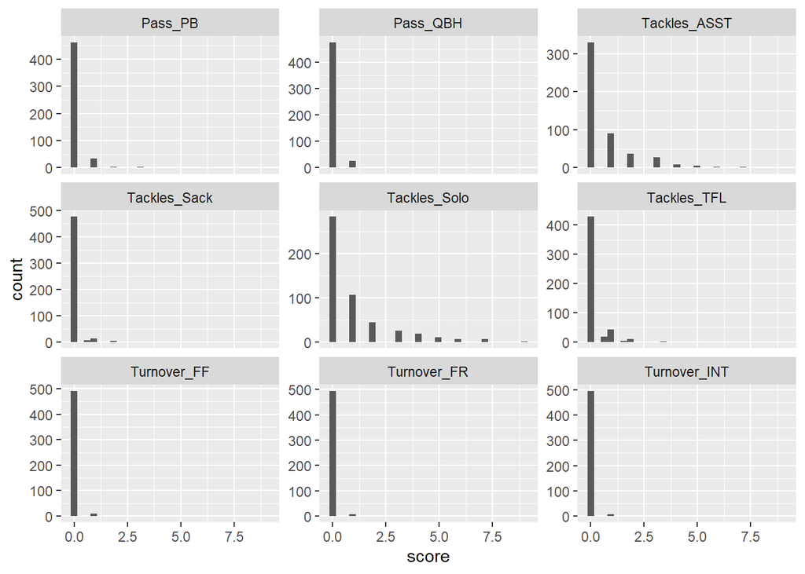

```r
ggplot(defClean, aes(x = score)) + geom_histogram() + facet_wrap(~stat, scales = 'free_y')
```

Turnovers (Turnover_FF, Turnover_FR, Turnover_INT) and Tackles_Sack are rare defensive skills.

3. Did ISU have better defense against Iowa or Notre Dame? Answer this question by creating a scatterplot with x- and y-axes being the number of solo tackles (of each player). A large number of solo tackles is an indicator of good defense.

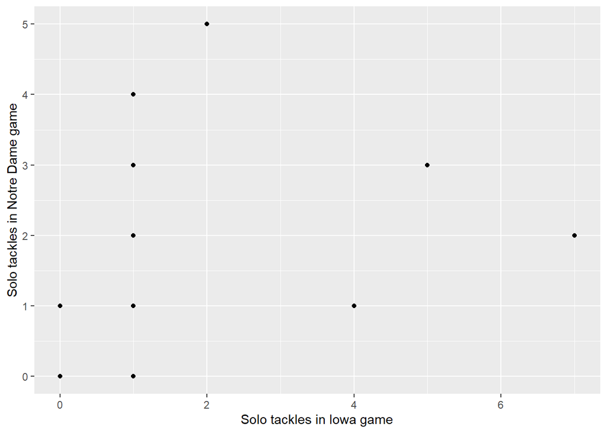

```r
soloTackles <- defClean %>%
               filter(Opponent_Opponent == 'Iowa' | Opponent_Opponent == 'Notre Dame', stat == 'Tackles_Solo') %>%
    pivot_wider(names_from = Opponent_Opponent, values_from= score)

ggplot(soloTackles, aes(x=Iowa, y=`Notre Dame`)) + geom_point() + xlab('Solo tackles in Iowa game') + ylab('Solo tackles in Notre Dame game')
```

According to the plot, Iowa State had better defense in the Notre game, because the plot shows more points with 2 or more solo tackles.

4. Separate the `Hometown` column into two columns, namely the city and the state. Print the first few rows of these two columns. (Hint: look at the sep= argument of separate)

```r
bioClean <- bioClean %>%
  separate(Hometown, into = c("City", "State"), sep = ", ")
head(bioClean)
```

```
## # A tibble: 6 x 8
##   Name         Position     Height Weight Class       City      State Highschool
##   <fct>        <chr>         <dbl>  <dbl> <chr>       <chr>     <chr> <chr>
## 1 Akers, Land~ Wide Receiv~    6      188 Redshirt S~ Cedar Ra~ Iowa  Washington
## 2 Allen, Chase Tight End       6.7    245 Redshirt S~ Nixa      Mo.   Nixa
## 3 Anderson, E~ Wide Receiv~    6.5    204 Redshirt F~ Seffner   Fla.  Armwood
## 4 Assalley, C~ Placekicker     6      195 Redshirt S~ Napervil~ Ill.  Central
## 5 Azunna, Arn~ Defensive B~    6      190 Redshirt S~ Grand Pr~ Texas Lake Ridge
## 6 Bailey, Cor~ Defensive E~    6.3    235 Redshirt J~ Clarksda~ Miss. Clarksdale
```

5. How many players are there from each state?

```r
bioClean %>%
  group_by(State) %>%
  summarize(numPlayers = n())
```

```
## # A tibble: 19 x 2
##    State     numPlayers
##    <chr>          <int>
##  1 Ariz.              4
##  2 Ark.               1
##  3 Australia          1
##  4 Calif.             3
##  5 Fla.              10
##  6 Ga.                4
##  7 Ill.               5
##  8 Iowa              35
##  9 Kan.               3
## 10 Mich.              4
## 11 Minn.              4
## 12 Miss.              1
## 13 Mo.                6
## 14 Ohio               7
## 15 Okla.              2
## 16 Pa.                1
## 17 S.D.               2
## 18 Texas              6
## 19 Wis.               6
```

## Part three: Joining data frames

1. Find which states do the ISU defensive and offensive players come from. Create an appropriate summary.

```r
defWithHomes <- defClean %>%
  select(Name) %>%
  distinct() %>%
  left_join(bioClean, by = "Name")

defWithHomes %>%
  group_by(State) %>%
  summarize(numPlayers = n()) %>%
  na.omit() %>%
  arrange(desc(numPlayers))
```

```
## # A tibble: 12 x 2
##    State  numPlayers
##    <chr>       <int>
##  1 Iowa            7
##  2 Fla.            4
##  3 Ga.             3
##  4 Ohio            3
##  5 Calif.          2
##  6 Mo.             2
##  7 Okla.           2
##  8 Texas           2
##  9 Wis.            2
## 10 Ark.            1
## 11 Kan.            1
## 12 Mich.           1
```

```r
offWithHomes <- offClean %>%
  select(Name) %>%
  distinct() %>%
  left_join(bioClean, by = "Name")

offWithHomes %>%
  group_by(State) %>%
  summarize(numPlayers = n()) %>%
  na.omit() %>%
  arrange(desc(numPlayers))
```

```
## # A tibble: 11 x 2
##    State numPlayers
##    <chr>      <int>
##  1 Fla.           2
##  2 Okla.          2
##  3 Ariz.          1
##  4 Ark.           1
##  5 Ga.            1
##  6 Ill.           1
##  7 Iowa           1
##  8 Kan.           1
##  9 Mo.            1
## 10 Ohio           1
## 11 Texas          1
```

2. How does the performance of quarterback Brock Purdy relate to the performance of the ISU team?

```r
offClean$YdsResponsibleFor <- rowSums(offClean[,c("Rushing_YDS", "Receiving_YDS", "Passing_YDS")], na.rm=TRUE)
offClean %>%
  group_by(Name) %>%
  summarize(AvgYdsResponsibleFor = mean(YdsResponsibleFor)) %>%
  arrange(desc(AvgYdsResponsibleFor))
```

```
## # A tibble: 17 x 2
##    Name                AvgYdsResponsibleFor
##    <fct>                              <dbl>
##  1 Purdy, Brock                      325.
##  2 Hall, Breece                       95.8
##  3 Jones, Deshaunte                   71.6
##  4 Milton, Tarique                    55.5
##  5 Kolar, Charlie                     53.6
##  6 Pettway, La'Michael                52
##  7 Lang, Johnnie                      24.3
##  8 Mitchell, Re-al                    23.4
##  9 Shaw Jr., Sean                     21
## 10 Croney Jr., Sheldon                13
## 11 Allen, Chase                       12.8
## 12 Brock, Jirehl                      12
## 13 Nwangwu, Kene                       9.46
## 14 Akers, Landen                       9
## 15 Soehner, Dylan                      8.92
## 16 Wilson, Darren                      4.54
## 17 Scates, Joe                         2.5
```

I added a conglomerate statistic for offensive players that is Yards Responsible For which consists of a sum of passing, rushing and receiving. Then averaged the stat for each player. It is obvious that Brock Purdy’s performance has the greatest single impact on the Iowa State team.

3. Which ISU player(s) made big progress over the last year?

```r
defense18 <- read_excel('cyclonesFootball2018.xlsx', sheet='Defensive')
defCleanWide18 <- defense18 %>%
              mutate(across(c("Name", "Opponent_Opponent"), as.factor)) %>%
              mutate_if(is.character, as.numeric, na.rm = TRUE)
defCleanWide19 <- defCleanWide

defCleanWide18 <- defCleanWide18 %>%
  group_by(Name) %>%
  select(-Opponent_Opponent) %>%
  summarize_all(list(mean), na.rm=TRUE)

defCleanWide19 <- defCleanWide19 %>%
  group_by(Name) %>%
  select(-Opponent_Opponent) %>%
  summarize_all(list(mean), na.rm=TRUE)


colnames(defCleanWide18) <- paste("Last", colnames(defCleanWide18), sep = "_")
colnames(defCleanWide19) <- paste("This", colnames(defCleanWide19), sep = "_")
DefCompare <- inner_join(defCleanWide18, defCleanWide19, by = c("Last_Name" = "This_Name"))
DefCompare$DiffTacklesSolo <- DefCompare$This_Tackles_Solo - DefCompare$Last_Tackles_Solo
DefCompare$DiffTacklesSack <- DefCompare$This_Tackles_Sack - DefCompare$Last_Tackles_Sack
DefCompare$DiffTacklesAsst <- DefCompare$This_Tackles_ASST - DefCompare$Last_Tackles_ASST

DefCompare %>%
  select(Last_Name, DiffTacklesSolo, DiffTacklesSack, DiffTacklesAsst) %>%
  arrange(desc(DiffTacklesSolo)) %>%
  head(1)
```

```
## # A tibble: 1 x 4
##   Last_Name         DiffTacklesSolo DiffTacklesSack DiffTacklesAsst
##   <fct>                       <dbl>           <dbl>           <dbl>
## 1 Johnson , Anthony            1.78           0.154             0.5
```

```r
DefCompare %>%
  select(Last_Name, DiffTacklesSolo, DiffTacklesSack, DiffTacklesAsst) %>%
  arrange(desc(DiffTacklesSack)) %>%
  head(1)
```

```
## # A tibble: 1 x 4
##   Last_Name     DiffTacklesSolo DiffTacklesSack DiffTacklesAsst
##   <fct>                   <dbl>           <dbl>           <dbl>
## 1 Vance, O'Rien            1.56           0.405            1.76
```

```r
DefCompare %>%
  select(Last_Name, DiffTacklesSolo, DiffTacklesSack, DiffTacklesAsst) %>%
  arrange(desc(DiffTacklesAsst)) %>%
  head(1)
```

```
## # A tibble: 1 x 4
##   Last_Name     DiffTacklesSolo DiffTacklesSack DiffTacklesAsst
##   <fct>                   <dbl>           <dbl>           <dbl>
## 1 Vance, O'Rien            1.56           0.405            1.76
```

These result shows the difference of the average of each player’s important stats last season versus this season. We see Anthony Johnson most improved in Solo tackles and O’Rien Vance most improved in Sacks and Assisted Tackles.

```r
offense18 <- read_excel('cyclonesFootball2018.xlsx', sheet='Offensive')
offCleanWide18 <- offense18 %>%
              mutate(across(c("Name", "Opponent_Opponent"), as.factor)) %>%
              mutate_if(is.character, as.numeric, na.rm = TRUE)
offCleanWide19 <- offClean

offCleanWide18 <- offCleanWide18 %>%
  group_by(Name) %>%
  select(-Opponent_Opponent) %>%
  summarize_all(list(mean), na.rm=TRUE)

offCleanWide19 <- offCleanWide19 %>%
  group_by(Name) %>%
  select(-Opponent_Opponent) %>%
  summarize_all(list(mean), na.rm=TRUE)

offCleanWide18
```

```
## # A tibble: 15 x 11
##    Name  Receiving_REC Receiving_YDS Receiving_TD Rushing_ATT Rushing_YDS
##    <fct>         <dbl>         <dbl>        <dbl>       <dbl>       <dbl>
##  1 Aker~        0.769         13.9         0         NaN          NaN
##  2 Alle~        1             10.5         0         NaN          NaN
##  3 Butl~        4.62         101.          0.692     NaN          NaN
##  4 Eato~        2.08          23.4         0.154     NaN          NaN
##  5 John~        0.0833         0.917       0         NaN          NaN
##  6 Jone~        3.31          28.2         0.308     NaN          NaN
##  7 Kemp~      NaN            NaN         NaN         NaN          NaN
##  8 Kola~        0.846         10.5         0.231     NaN          NaN
##  9 Lang~        0.333          2.5         0           1.83         6.58
## 10 Milt~        2.62          32.1         0.0769      0.0769       0.231
## 11 Mont~        1.83          13.1         0          21.4        101.
## 12 Nola~      NaN            NaN         NaN           1.4         -2.6
## 13 Nwan~        0.154          0.846       0           3           12.1
## 14 Purd~      NaN            NaN         NaN          10           30.8
## 15 Seon~        0.385          3.46        0.0769    NaN          NaN
## # ... with 5 more variables: Rushing_TD <dbl>, `Passing_CMP-ATT` <dbl>,
## #   Passing_YDS <dbl>, Passing_TD <dbl>, Passing_INT <dbl>
```

```r
offCleanWide19
```

```
## # A tibble: 17 x 12
##    Name  Rushing_ATT Rushing_YDS Rushing_TD Receiving_REC Receiving_YDS
##    <fct>       <dbl>       <dbl>      <dbl>         <dbl>         <dbl>
##  1 Aker~      0.0769       0.615     0             0.692          8.38
##  2 Alle~    NaN          NaN       NaN             1.31          12.8
##  3 Broc~      2.25        12         0           NaN            NaN
##  4 Cron~      2.5          8         0.0833        0.833          5
##  5 Hall~     15.5         74.8       0.75          1.92          21
##  6 Jone~      0.308        0.231     0             5.85          67.5
##  7 Kola~    NaN          NaN       NaN             3.92          53.6
##  8 Lang~      4.17        19.8       0.25          0.667          4.5
##  9 Milt~    NaN          NaN       NaN             2.69          55.5
## 10 Mitc~      2.2         20         0.2           0.2            0.6
## 11 Nwan~      1.23         8.85      0             0.0769         0.615
## 12 Pett~    NaN          NaN       NaN             4.23          52
## 13 Purd~      7.15        19.2       0.615       NaN            NaN
## 14 Scat~    NaN          NaN       NaN             0.2            2.5
## 15 Shaw~    NaN          NaN       NaN             1.36          21
## 16 Soeh~    NaN          NaN       NaN             0.583          8.92
## 17 Wils~    NaN          NaN       NaN             0.385          4.54
## # ... with 6 more variables: Receiving_TD <dbl>, `Passing_CMP-ATT` <dbl>,
## #   Passing_YDS <dbl>, Passing_TD <dbl>, Passing_INT <dbl>,
## #   YdsResponsibleFor <dbl>
```

```r
colnames(offCleanWide18) <- paste("Last", colnames(offCleanWide18), sep = "_")
colnames(offCleanWide19) <- paste("This", colnames(offCleanWide19), sep = "_")
OffCompare <- inner_join(offCleanWide18, offCleanWide19, by = c("Last_Name" = "This_Name"))
OffCompare$DiffRecYds <- OffCompare$This_Receiving_YDS - OffCompare$Last_Receiving_YDS
OffCompare$DiffPassingYds <- OffCompare$This_Passing_YDS - OffCompare$Last_Passing_YDS
OffCompare$DiffRushingYds <- OffCompare$This_Rushing_YDS - OffCompare$Last_Rushing_YDS

OffCompare %>%
  select(Last_Name, DiffRecYds, DiffPassingYds, DiffRushingYds) %>%
  arrange(desc(DiffRecYds)) %>%
  head(1)
```

```
## # A tibble: 1 x 4
##   Last_Name      DiffRecYds DiffPassingYds DiffRushingYds
##   <fct>               <dbl>          <dbl>          <dbl>
## 1 Kolar, Charlie       43.1            NaN            NaN
```

```r
OffCompare %>%
  select(Last_Name, DiffRecYds, DiffPassingYds, DiffRushingYds) %>%
  arrange(desc(DiffPassingYds)) %>%
  head(1)
```

```
## # A tibble: 1 x 4
##   Last_Name    DiffRecYds DiffPassingYds DiffRushingYds
##   <fct>             <dbl>          <dbl>          <dbl>
## 1 Purdy, Brock        NaN           81.3          -11.6
```

```r
OffCompare %>%
  select(Last_Name, DiffRecYds, DiffPassingYds, DiffRushingYds) %>%
  arrange(desc(DiffRushingYds)) %>%
  head(1)
```

```
## # A tibble: 1 x 4
##   Last_Name     DiffRecYds DiffPassingYds DiffRushingYds
##   <fct>              <dbl>          <dbl>          <dbl>
## 1 Lang, Johnnie          2            NaN           13.2
```

These results are for the offensive players. Some NaN exist in categories where players have not done such an action, however this will not impact finding the “improvers”. In Receiving Yards, Charlie Kolar has improved the most since last season. Brock Purdy has improved the most in Passing Yards. And Johnnie Lang has improved the most in Rushing Yards.